# IODS course project

### **For bonus point**

```
## Call:
## lda(km$cluster ~ ., data = boston_scaled)
##
## Prior probabilities of groups:
##          1          2          3          4
## 0.20158103 0.07509881 0.19367589 0.52964427
##
## Group means:
##         crim          zn      indus        chas        nox         rm
## 1  0.8483345 -0.48724019  1.0838758  0.03646311  1.0056331 -0.4303477
## 2  1.3492360 -0.48724019  0.9897542 -0.16872117  1.0270785 -0.3118831
## 3 -0.3339206 -0.06065643  0.2692277 -0.03128211  0.2376613 -0.1349063
## 4 -0.3920779  0.27670879 -0.6513071  0.02148438 -0.6152775  0.2573427
##          age        dis        rad        tax    ptratio      black
## 1  0.7580706 -0.8158193  1.5470081  1.5425013  0.8035142  0.1657159
## 2  0.7577700 -0.8551100  1.4873328  1.4032499  0.6805778 -3.2738722
## 3  0.1674623 -0.2199834 -0.5424068 -0.0127896 -0.3645390  0.1641960
## 4 -0.4572006  0.5121870 -0.6013344 -0.7813629 -0.2690134  0.3410930
##          lstat        medv
## 1  0.731117686 -0.55489146
## 2  1.091661367 -1.02276656
## 3  0.008659037 -0.01676994
## 4 -0.436215379  0.36234147
##
## Coefficients of linear discriminants:
##                 LD1          LD2         LD3
## crim    -0.02900417 -0.109785749  0.03375586
## zn      -0.19648159  0.018768383  0.07254133
## indus   -0.19940721  0.219942257  0.12323006
## chas    -0.02236389 -0.029467625  0.04910306
## nox     -0.15069744  0.369970110 -0.36479353
## rm       0.04536796 -0.072071494  0.06814103
## age      0.11004807 -0.006954389  0.04561926
## dis      0.31619537  0.106412451  0.19414301
## rad     -1.08620196  0.150475218  3.04910343
## tax     -3.60381517  1.194475231 -2.69488949
## ptratio -0.08966477 -0.081475663  0.19122603
## black    0.56337256  2.917384656  0.20070643
## lstat    0.06017686  0.015435570  0.06846218
## medv    -0.07470967  0.076763452 -0.12387299
##
## Proportion of trace:
##    LD1    LD2    LD3
## 0.7954 0.1812 0.0234
```

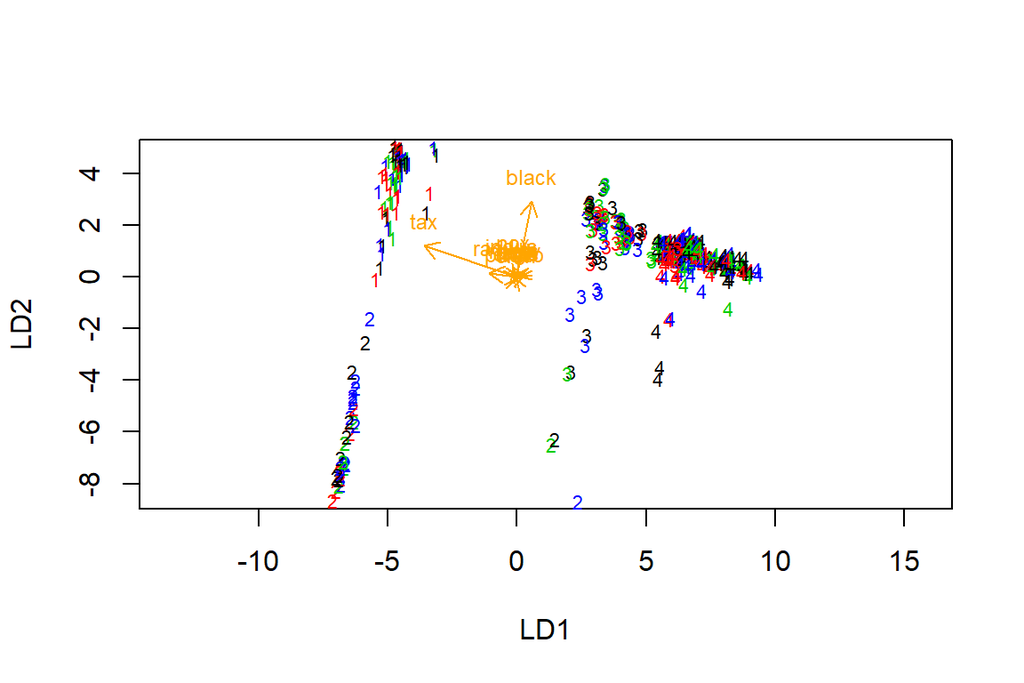

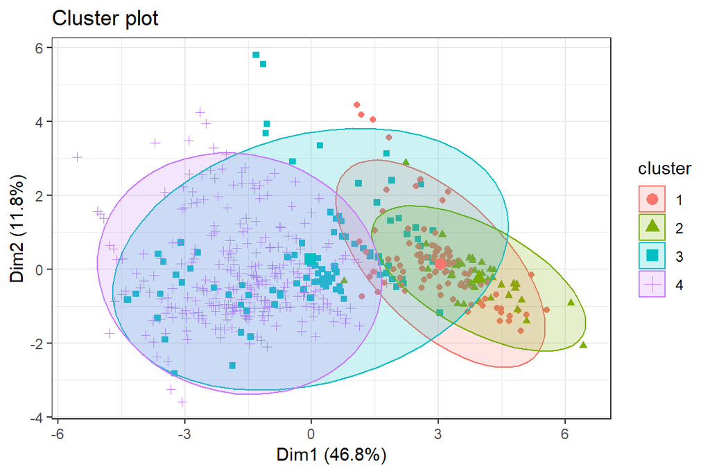

- The tax, rad and black seems to be the most influential variables in the LDA plot.

### **References**

https://campus.datacamp.com/courses/helsinki-open-data-science/clustering-and-classification?ex=11

https://stat.ethz.ch/R-manual/R-devel/library/MASS/html/Boston.html

https://rpubs.com/Nolan/298913

# Dimensionality Reduction Technique

### **1. Data Overview**

```
## 'data.frame':    155 obs. of  8 variables:
##  $ Edu2.FM  : num  1.007 0.997 0.983 0.989 0.969 ...
##  $ Labo.FM  : num  0.891 0.819 0.825 0.884 0.829 ...
##  $ Edu.Exp  : num  17.5 20.2 15.8 18.7 17.9 16.5 18.6 16.5 15.9 19.2 ...
##  $ Life.Exp : num  81.6 82.4 83 80.2 81.6 80.9 80.9 79.1 82 81.8 ...
##  $ GNI      : int  64992 42261 56431 44025 45435 43919 39568 52947 42155 32689 ...
##  $ Mat.Mor  : int  4 6 6 5 6 7 9 28 11 8 ...
##  $ Ado.Birth: num  7.8 12.1 1.9 5.1 6.2 3.8 8.2 31 14.5 25.3 ...
##  $ Parli.F  : num  39.6 30.5 28.5 38 36.9 36.9 19.9 19.4 28.2 31.4 ...
```

```
## [1] 155   8
```

- The data used in analysis was based on human development report by United Nations Development Programme. The Human Development and Gender Inequality indices will be analysed. The original dataset has combined indicators from different parts of the world. Out of them, some variables are selected for the analysis. The indicators of Human development index are Gross National Income per capita, Life expectancy at birth, Maternal mortality ratio, Adolescent birth rate and Expected years of schooling. The indicators for Gender Inequality Index are are Percetange of female representatives in parliament, Proportion of males and females with at least secondary education and Proportion of males and females in the labour force. The proportion of males and females in education and labor force variables has been modified. The first one is the the ratio of Female and Male populations with secondary education in each country. (i.e. edu2F / edu2M). The second one is the ratio of labour force participation of females and males in each country (i.e. labF / labM).
- The current dataset has 155 observations of 8 variables.
- More information about the dataset can be found at http://hdr.undp.org/en/content/human-development-index-hdi

**a. Summary of the data**

```
##     Edu2.FM          Labo.FM          Edu.Exp         Life.Exp
##  Min.   :0.1717   Min.   :0.1857   Min.   : 5.40   Min.   :49.00
##  1st Qu.:0.7264   1st Qu.:0.5984   1st Qu.:11.25   1st Qu.:66.30
##  Median :0.9375   Median :0.7535   Median :13.50   Median :74.20
##  Mean   :0.8529   Mean   :0.7074   Mean   :13.18   Mean   :71.65
##  3rd Qu.:0.9968   3rd Qu.:0.8535   3rd Qu.:15.20   3rd Qu.:77.25
##  Max.   :1.4967   Max.   :1.0380   Max.   :20.20   Max.   :83.50
##       GNI            Mat.Mor         Ado.Birth         Parli.F
##  Min.   :   581   Min.   :   1.0   Min.   :  0.60   Min.   : 0.00
##  1st Qu.:  4198   1st Qu.:  11.5   1st Qu.: 12.65   1st Qu.:12.40
##  Median : 12040   Median :  49.0   Median : 33.60   Median :19.30
##  Mean   : 17628   Mean   : 149.1   Mean   : 47.16   Mean   :20.91
##  3rd Qu.: 24512   3rd Qu.: 190.0   3rd Qu.: 71.95   3rd Qu.:27.95
##  Max.   :123124   Max.   :1100.0   Max.   :204.80   Max.   :57.50
```

- The minimum and maximum value for ratio of female to male rates with at least secondary education are 0.17 and 1.5 resp. The minimum and maximum value of Labour force participation rate, female-male ratio are 0.18 and 1.04 resp. The minimum value of female-male shares in secondary education and labor force shows the limitations of women to access the basic rights to have atleast secondary education and employment in some of the countries in the current dataset. The maximum number of maternal mortality rate is 1100 (deaths per 100,000 live births). The minimum value of GNI per capita is 581 which seems to be very low in terms of nation and human development.

### **2. Graphical overview of the data and relationship between variables**

**a. Graphical Overview using corrplot**

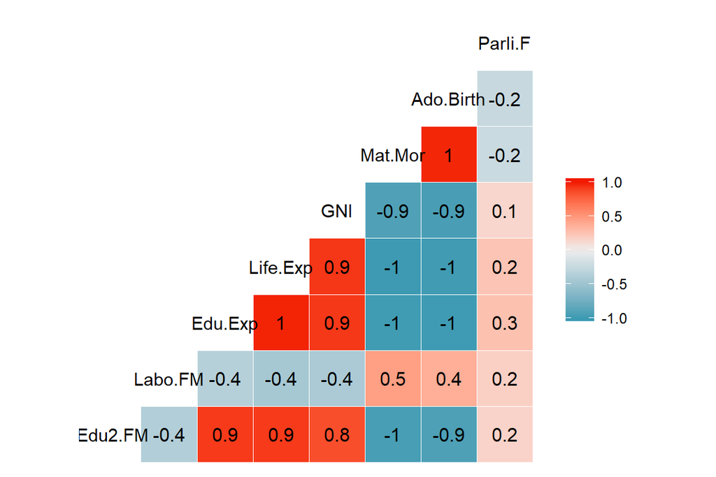

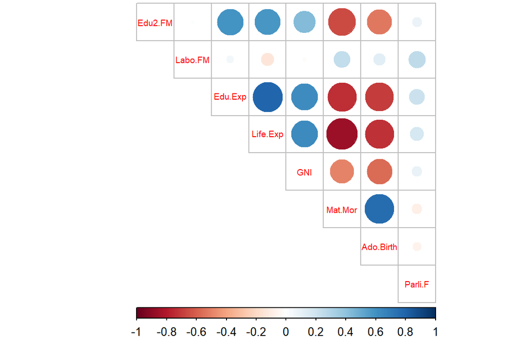